# Module 1: Water

**Module 1: Water is part of the Science Core Heuristics for Open Science Outcomes in Learning (SCHOOL)**, part of the [NASA Transform to Open Science (TOPS)](https://zenodo.org/records/8087116) Training (TOPST) initiative.

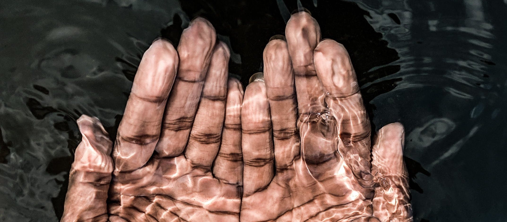

# Code of Conduct

- Review other codes
- Carpentries
- NASA TOPS - If possible this is the default, perhaps with some edits, since we are a NASA TOPS project: https://nasa.github.io/Transform-to-Open-Science-Book/About/CODE_OF_CONDUCT.html
- NASA OpenScapes.

# Module 1 objectives

- Students will gain an understanding of the water cycle
- Students will learn the role humans play in the water cycle.
- Student will learn about water surpluses and deficits (anomalies)
- Students will learn how to access GLDAS data from the NASA SEDAC website (https://www.dante-project.org/sedacr)
- Students will learn how to access MODIS NRT flood data
- Students will learn how to store data locally
- Students will learn how to subset a global data set to a predefined area of interest (AOI). (GeoBoundaries?)
- Students will learn how to summarize the data set using an area of interest
- Students will learn how to visualize results as maps and graphs using R(?)
- Students will learn how to estimate impacts on populations at risk (PES, POPGRID, perhaps also infrastructure with OSM)
- Students will learn how to share their results to the cloud (using Binder?)

# Credits

M1 Banner Photo by Jacob Kelvin.J